# Windows上安装Tensorflow踩的坑

余文华

2017年3月14日

## 前言

```
看到Rstudio中开始支持Tensorflow，本人是欣喜若狂的，同时TensorFlow官网从16年9月低开始支持windows安装了，不免想试试在自己的Windows上用R跑跑tensorflow的。可是事与愿违，倒腾了一周今天正式宣布，暂停这一实践。但失败的尝试也不能白失败了，拿出来晒晒说不定有高人指点呢，特此把踩过的坑述说一二，一来是寻求帮助，二来也是警惕来者，“此处有坑，请小心绕道”吧。
```

## 在Rstudio运用R实现Tensorflow的一般步骤

```
按照[TensorFlow for R](https://rstudio.github.io/tensorflow/index.html)官网说明，运用R实现Tensorflow主要包含4步(如下)，其中关键步骤在于安装好Tensorflow以及tensorflow R 包与python的连接。
```

1. 从[TensorFlow官网](https://www.tensorflow.org/get_started/os_setup.html#download-and-setup)安装TensorFlow.
2. 安装tensorflow R 包

```r
devtools::install_github("rstudio/tensorflow")
```

3. 载入TensorFlow

```r
Sys.setenv(TENSORFLOW_PYTHON="/usr/local/bin/python")
library(tensorflow)
```

4. 验证安装

```r
library(tensorflow)
sess = tf$Session()
hello <- tf$constant('Hello, TensorFlow!')
sess$run(hello)
```

## 踩过的一号坑——tensorflow在windows上的安装

```
在之前的文章中，曾经通过Docker的方法，实现了在windows上安装tensorflow，感兴趣的出门左转，在公众号查看“Deep Learning 学习（三）——在window下运行tensorfolw”。现在官网有了windows支持版，当然是要尝试尝试的。
官网给出windows安装tensorflow有两种方法：
```

- “native” pip
- Anaconda

  于是首先我尝试用Anaconda进行安装。在官网下载 Anaconda（目前有Anaconda2和Anaconda3，分别支持python2.7和python3.6），由于在windows中tensorflow需要python3，本人下载的Anaconda3。根据官网操作步骤，安装完成后，进入Anaconda prompt，进行如下操作

1.在conda独立空间中创建一个名为tensorflow的环境名，在这里需要加上“python = 3“ 表示在python3中建立环境”

2.激活创建的环境

3.安装tensorflow的CPU版本，当然也有GPU版本，但需要NVIDIA的显卡，小弟太穷，只能望“卡”兴叹了。

```
#1.在conda独立空间中创建一个名为tensorflow的环境
conda create -n tensorflow python = 3.5.2
#2.激活创建的环境
activate tensorflow
#3.安装tensorflow的CPU版本
(tensorflow)C:> pip install --ignore-installed --upgrade https://storage.googleapis.com/tensorflow/windows/cpu/tensorflow-1.0.1-cp35-cp35m-win_amd64.whl
```

```
经过几番尝试，成功在windows上安装上了Tensorflow，不免十分兴奋。验证如下图：
```

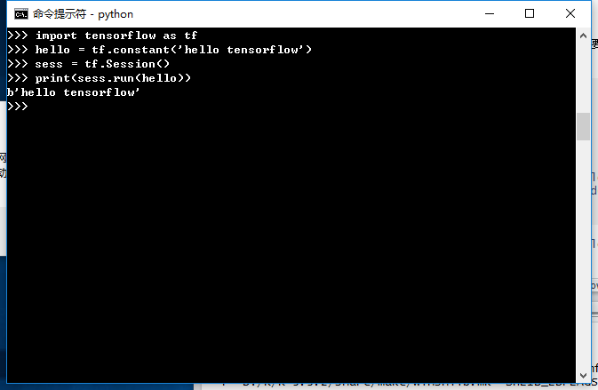

img1

```
但是兴奋得太早，Rstudio官网中有行小字：“NOTE: You should NOT install TensorFlow with Anaconda as there are issues with the way Anaconda builds the python shared library that prevent dynamic linking from R.” 直接给了我当头一棒，这里明确说明通过Anaconda安装tensorflow无法在R中实现，即“You should NOT install TensorFlow with Anaconda”！！（此处省略一万个感叹号…
```

## 踩过的二号坑——运用native pip 安装 tensorflow

```
回到原点，再次在windows上安装tensorflow，这次是采样pip方法。需要注意的坑有以下几点：
```

   ```
   pip3 install --upgrade tensorflow
   ```

   好吧，我承认第3点这个坑，我至今还没爬上来，原因是总出现如下错误：

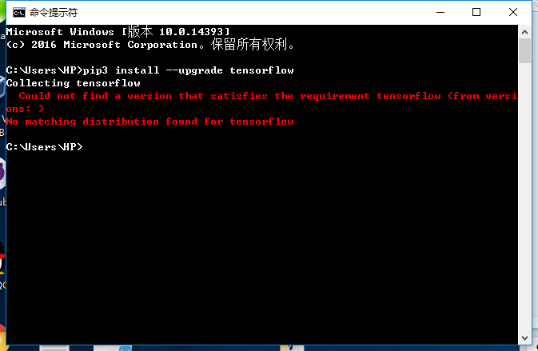

img2

在网上搜索了各种尝试均没有安装成功，其中的尝试有：

1. 在pip语句中加入“–ignore-installed”，仍然除现同一错误。

```
pip install --upgrade --ignore-installed tensorflow
```

2. 把whl文件下载到本地，在文件夹下进行安装

   ```
   pip install tensorflow-1.0.0-cp35-cp35m-win_amd64.whl
   ```

   提示“tensorflow-1.0.0-cp35-cp35m-win_amd64.whl is not a supported wheel on this platform”

3.在网络中安装

```
pip install --ignore-installed --upgrade https://storage.googleapis.com/tensorflow/windows/cpu/tensorflow-1.0.1-cp35-cp35m-win_amd64.whl
```

4. 把“cp35-cp35m”改成“py3-none”

   ```
   pip install --ignore-installed --upgrade https://storage.googleapis.com/tensorflow/windows/cpu/tensorflow-1.0.1-py3-none-win_amd64.whl
   ```

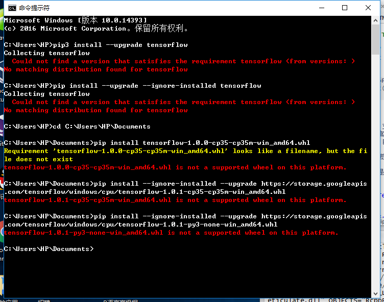

img3

```
还有其他尝试，但都一一失败，也有博客认为安装“pip3 install --upgrade tensorflow”出现“No matching distribution found for tensorflow”是网络原因，但我也尝试了很多，都没有安装成功。
```

## 其他坑——请准备最新版的Rstudio

```
当然还有其他浅点的“坑”，比如安装devtools::install_github("rstudio/tensorflow")时，需要最新版Rtools，并先保证Rstudio是v 1.0或更高版本等。
```

## 写在最后

```
其实运用R实现tensorflow并不需要在windows环境下，并且不得不承认的是windows本身就是一个“奇深无比的坑”。但是既然官网均有安装示例，又说明通过R实现tensorflow是十分可行的思路。也让python粉们看看，tensorflow 绝不仅仅是python的“专利”。
最后，再次发出“求救信号”，对本人没爬出来的坑，可否指点一二，再次不胜感激！
```